### 0.0.1 Introduction:

In this project, I want to address the question: “Does the proportion of gun ownership depend on whether or not the group has a college degree?”. Broadly, is there an association between inclination to own a gun to the fact that whether or not one has a college degree.

The reason why I picked this question is that I was curious if more educated communities stay away from violent weapons.

### 0.0.3 Exploratory data analysis:

```
##                  college   nocollege
## owngun       121.0000000 317.0000000
## donot-owngun 239.0000000 597.0000000
## proportion     0.2164580   0.2253021
```

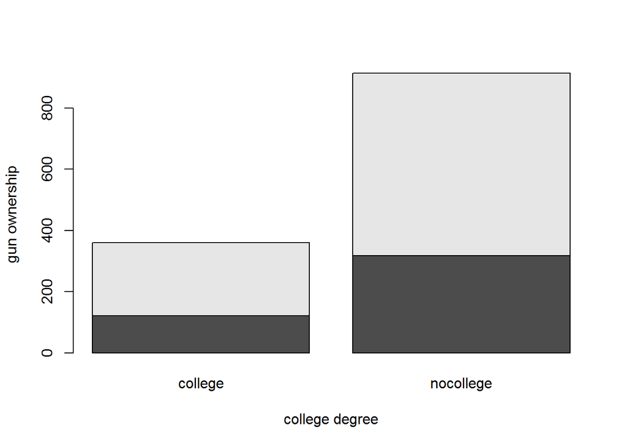

- From the table, we see a slightly higher proportion of gun owners from the group with no college degree. However, this is a very small difference. We have to find out if this difference is due to  
  the difference in the level of college degree or due to chance, using both confidence interval and Hypothesis testing.

### 0.0.4 Inference:

The question for inference is, how do people with college degree compare with people without a college degree with respect to gun ownership.

- Null Hypothesis: There is no difference in the proportion of gun ownership between people with  
  college degree and people without college degree.
- Alternative Hypothesis: The proprtion of gun ownership is different between people with college  
  degree and people without a college degree.

We will compute Confidence Interval and cross check that result with Hypothesis testing.

#### 0.0.4.1 Conditions for CLT for Confidence interval

The point_estimate of difference between the two proportions is:

```
## [1] -0.0088441
```

- Independence:
1. Within group: The sample is a random sample of people and is less than 10% of all the people who has a college degree in 2012 and people who do not.
2. Between group: The sample of people who go to college are independent of people who do not go.
- sample size The below sample sizes for both groups are greater than 10.

```
## [1] 121
```

```
## [1] 438
```

```
## [1] 317
```

```
## [1] 1090
```

The confidence interval is of the form (point_estimate (+/-) Margin or error). We need to find the margin of error, which is Z_score X Standard Error. For a 95% confidence interval Z_score is set to 1.96. The Standard error is:

```
## [1] 0.02067505
```

For a 95% confidence interval, the difference in the gun ownership proportion is:

```
## [1] -0.04936721  0.03167900
```

Let’s now proceed to Hypothesis testing to verify the result.

Null Hypothesis is: H0: p_col-p_nocol = 0 And the alternative hypothesis: HA: p_col-p_nocol != 0

We need to get Pooled proportions for the Null value. Pooled proportion for the Null Hypothesis is:

```
## [1] 0.2227874
```

Conditions for Hypothesis testing:

- Independence
- Within group The sample is a random sample of people and is less than 10% of all the people who go to or not to go college
- Between group The sample of people who go to college are independent of people who do not go.
- Sample size Using the pooled proportions, we can verify the conditions for the sample sizes for both groups to make sure they are greater than 10.

```
## [1] 124.5381
```

```
## [1] 434.4619
```

```
## [1] 313.4619
```

```
## [1] 1093.538
```

The Standard Error is also calculated from the Pooled proportion and the sample size of the individual groups:

```
## [1] 0.02080434
```

The sample distribution of the difference between the two proportions is nearly normal with mean=0, and standard error = 0.02080434.

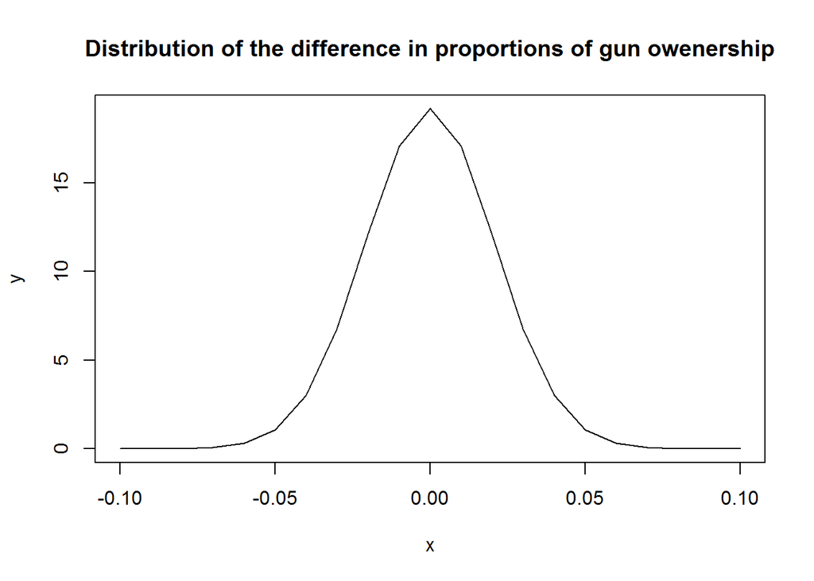

The p-value is obtained as follows: point-estimate of the differense is

```
## [1] -0.0088441
```

p_value is the probability of seeing the difference of the two proportions given the Null Hypothesis is True.

First we calculate the Z score for the point estimate. Z_score is:

```
## [1] -0.4251084
```

p_value corresposding to the Z_score is:

```
## [1] 0.6646212
```

We obtained a p_value of 0.664, which is very high compared to the 5% significance. Because of that we fail to reject the Null Hypothesis. So there is not enough evidence that the gun ownership proportions differ based on whether a person has a college degree or not.

The same result is also abtained by looking at the confidence interval we obtained: (-0.04936721 0.03167900). As we see, we have ‘0’ in our confidence interval, which indicates that we cannot infact reject the Null Hypothesis.

### 0.0.5 Conclusion:

For future study, I am interested in bringing in more factors, like political affiliation, and Opinion of family income to see if those factorsinfluence gun ownership.